# Question 3 - WebText API Proof of Concept

R.P Molefe (EDUV4838900)

2026-11-14

# Question 3.1 - Fair-use web scraping into an R data structure

**Website chosen:** Wikipedia article *“Big data”*. Wikipedia text is published under the Creative Commons BY-SA licence. The page’s `robots.txt` permission is verified before scraping, a delay is applied after the request and only one page is requested, in line with fair use of web scraping.

```r
# Q3.1
url <- "https://en.wikipedia.org/wiki/Big_data"
allowed <- paths_allowed(url)
cat("Scraping allowed by robots.txt:", allowed, "\n")
```

```
## Scraping allowed by robots.txt: TRUE
```

```r
stopifnot(allowed)

page <- read_html(url); Sys.sleep(2)
xml2::xml_remove(html_elements(page, "style, script, sup.reference, .mw-editsection"))
paras <- page |> html_elements("#mw-content-text .mw-parser-output > p") |> html_text2()
if (length(paras) < 5) paras <- page |> html_elements("#mw-content-text p") |> html_text2()
if (length(paras) < 5) paras <- page |> html_elements("p") |> html_text2()
cat("Paragraphs scraped:", length(paras), "\n")
```

```
## Paragraphs scraped: 78
```

```r
stopifnot(length(paras) >= 5)

web_df <- tibble(para_id = seq_along(paras), text = paras) |>
  filter(str_trim(text) != "")
str(web_df)
```

```
## tibble [77 × 2] (S3: tbl_df/tbl/data.frame)
##  $ para_id: int [1:77] 2 3 4 5 6 7 8 9 10 11 ...
##  $ text   : chr [1:77] "Big data primarily refers to data sets that are too large or complex to be dealt with by traditional data-proce"| __truncated__ "Big data analysis challenges include capturing data, data storage, data analysis, search, sharing, transfer, vi"| __truncated__ "Current usage o…
```

```r
head(web_df |> mutate(text = substr(text, 1, 150)), 5)
```

```
## # A tibble: 5 × 2
##   para_id text
##     <int> <chr>
## 1       2 "Big data primarily refers to data sets that are too large or complex…
## 2       3 "Big data analysis challenges include capturing data, data storage, d…
## 3       4 "Current usage of the term big data tends to refer to the use of pred…
## 4       5 "The size and number of available data sets have grown rapidly as dat…
## 5       6 "Relational database management systems and desktop statistical softw…
```

# Question 3.2 - Text preprocessing

The following preprocessing techniques were applied: removal of citation markers such as `[12]` and `[citation needed]`, removal of bracketed asides, transliteration and removal of non-ASCII characters, whitespace normalisation, removal of very short paragraphs, sentence segmentation, word tokenisation, stop-word and number removal, removal of short tokens and lemmatisation.

```r
# Q3.2
web_df <- web_df |>
  mutate(text = text |>
           str_remove_all("\\[(\\d+|citation needed|[a-z]|note \\d+)\\]") |>
           str_remove_all("\\.?mw-parser-output[^}]*\\}") |>
           str_replace_all("\\([^)]*\\)", " ") |>
           stringi::stri_trans_general("Latin-ASCII") |>
           str_replace_all("[^ -~]", " ") |>
           str_squish()) |>
  filter(nchar(text) > 40)

sentences <- web_df |>
  mutate(sentence = tokenizers::tokenize_sentences(text)) |>
  select(para_id, sentence) |>
  tidyr::unnest(sentence) |>
  mutate(sentence = str_squish(sentence)) |>
  filter(nchar(sentence) > 30) |>
  mutate(textrank_id = row_number())

words <- sentences |>
  tidytext::unnest_tokens(output = word, input = sentence) |>
  anti_join(stop_words, by = "word") |>
  filter(!str_detect(word, "\\d"), nchar(word) > 2) |>
  mutate(word = if_else(word == "data", word, lemmatize_words(word)))

cat("Paragraphs:", nrow(web_df), "| Sentences:", nrow(sentences), "| Clean tokens:", nrow(words), "\n")
```

```
## Paragraphs: 77 | Sentences: 263 | Clean tokens: 3187
```

```r
stopifnot(nrow(sentences) > 5)
head(sentences, 5)
```

```
## # A tibble: 5 × 3
##   para_id sentence                                                   textrank_id
##     <int> <chr>                                                            <int>
## 1       2 Big data primarily refers to data sets that are too large…           1
## 2       2 Data with many entries offers greater statistical power, …           2
## 3       3 Big data analysis challenges include capturing data, data…           3
## 4       3 Big data was originally associated with three key concept…           4
## 5       3 The analysis of big data that have only volume, velocity,…           5
```

# Question 3.3 - Text summarisation

## Technique 1 - TextRank (graph-based extractive summary)

Each sentence is a node in a graph, edges are weighted by the words two sentences share, and the PageRank algorithm selects the most central sentences.

```r
# Q3.3
tr <- textrank_sentences(data = sentences |> select(textrank_id, sentence),
                         terminology = words |> select(textrank_id, word))
textrank_summary <- summary(tr, n = 5, keep.sentence.order = TRUE)
cat(paste0("- ", textrank_summary), sep = "\n")
```

```
## - By 2025, IDC predicts there will be 163 zettabytes of data.
## - Big data can be described by the following characteristics:
## - Other possible characteristics of big data are:
## - Systems up until 2008 were 100% structured relational data.
## - CRVS is one of the sources of big data for the governments.
```

## Technique 2 - Frequency-based (Luhn) summary

Each sentence is scored by the average normalised frequency of its important words.

```r
# Q3.3
freq <- words |> count(word, sort = TRUE) |> mutate(w = n / max(n))
luhn <- words |> inner_join(freq, by = "word") |>
  group_by(textrank_id) |> summarise(score = sum(w) / n(), .groups = "drop") |>
  inner_join(sentences, by = "textrank_id")
luhn_summary <- luhn |> slice_max(score, n = 5) |> arrange(textrank_id)
cat(paste0("- ", luhn_summary$sentence), sep = "\n")
```

```
## - Big data can be described by the following characteristics:
## - Other possible characteristics of big data are:
## - "Big data very often means 'dirty data' and the fraction of data inaccuracies increases with data volume growth."
## - The name big data itself contains a term related to size and this is an important characteristic of big data.
## - Big data often poses the same challenges as small data; adding more data does not solve problems of bias, but may emphasize other problems.
```

## Technique 3 - LexRank (cosine-similarity graph)

```r
# Q3.3
lex <- lexRank(sentences$sentence, n = 5, continuous = TRUE, Verbose = FALSE)
cat(paste0("- ", lex$sentence), sep = "\n")
```

```
## - Big data analysis challenges include capturing data, data storage, data analysis, search, sharing, transfer, visualization, querying, updating, information privacy, and data sources.
## - The name big data itself contains a term related to size and this is an important characteristic of big data.
## - Big data can be described by the following characteristics:
## - Other possible characteristics of big data are:
## - Current usage of the term big data tends to refer to the use of predictive analytics, user behavior analytics, or certain other advanced data analytics methods that extract value from big data, and seldom to a particular size of data set.
```

## Visualisation 1 - Most frequent terms

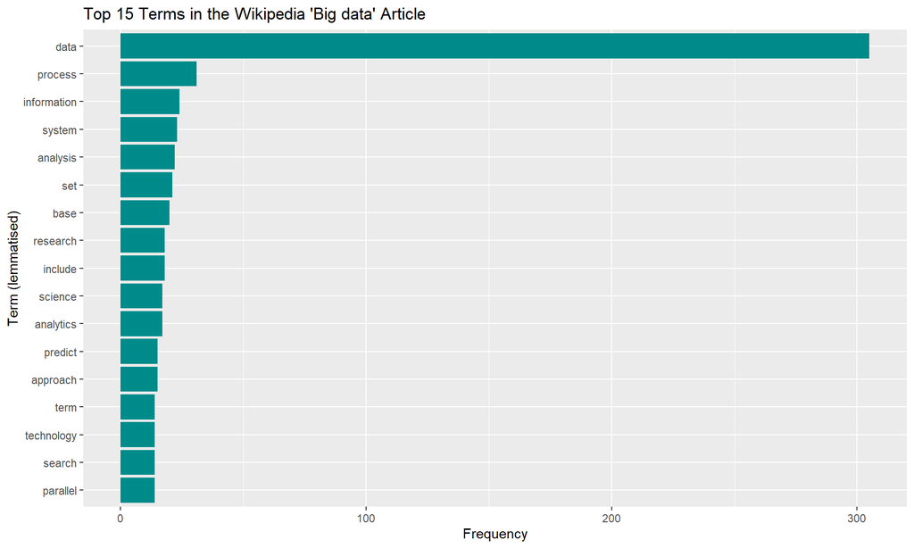

```r
# Q3.3
freq |> slice_max(n, n = 15) |>
  ggplot(aes(reorder(word, n), n)) + geom_col(fill = "darkcyan") + coord_flip() +
  labs(title = "Top 15 Terms in the Wikipedia 'Big data' Article",
       x = "Term (lemmatised)", y = "Frequency")
```

## Visualisation 2 - Word cloud

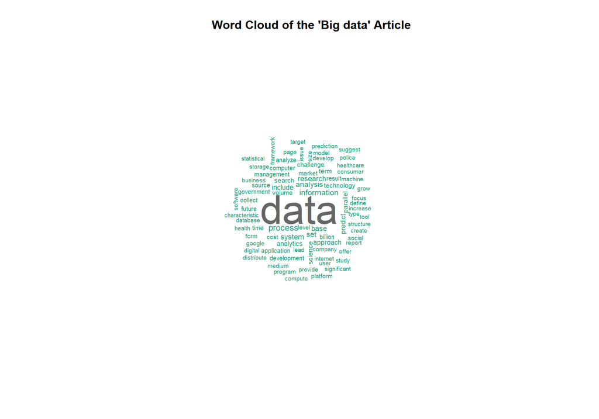

```r
# Q3.3
wordcloud(freq$word, freq$n, max.words = 80, random.order = FALSE, colors = brewer.pal(8, "Dark2"))
title("Word Cloud of the 'Big data' Article")
```

## Visualisation 3 - Sentence importance (TextRank) across the article

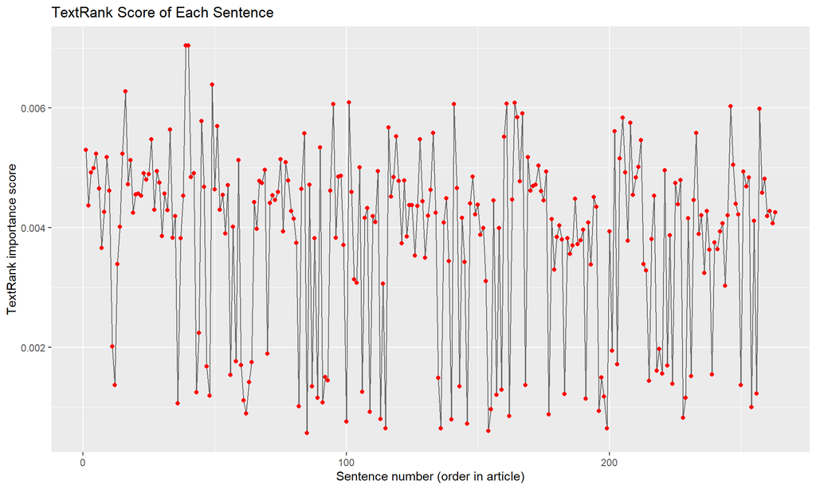

```r
# Q3.3
tr$sentences |>
  ggplot(aes(textrank_id, textrank)) + geom_line(colour = "grey40") + geom_point(colour = "red") +
  labs(title = "TextRank Score of Each Sentence", x = "Sentence number (order in article)",
       y = "TextRank importance score")
```

## Visualisation 4 - Bigram network

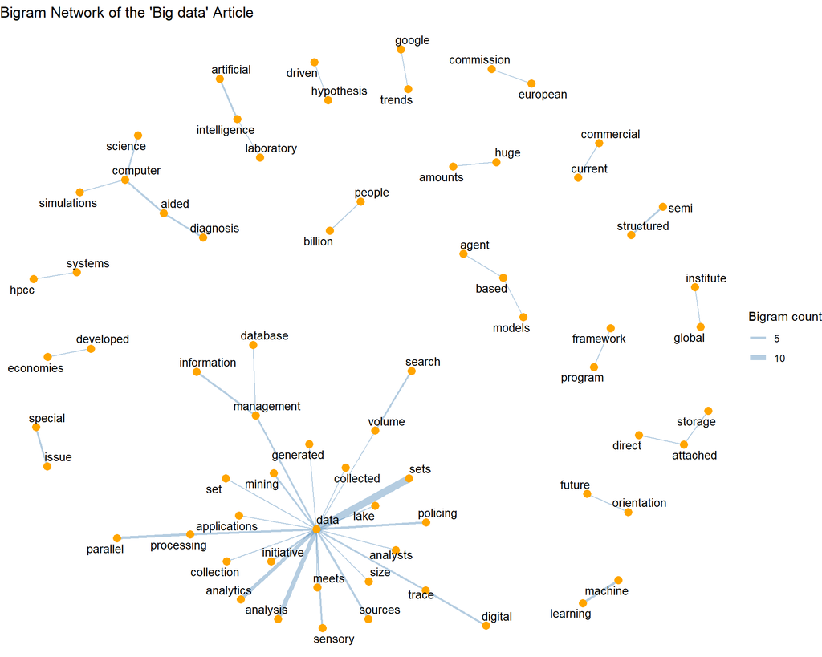

```r
# Q3.3
bigrams <- tibble(bigram = unlist(tokenizers::tokenize_ngrams(web_df$text, n = 2))) |>
  filter(!is.na(bigram)) |>
  separate(bigram, c("w1", "w2"), sep = " ") |>
  filter(!w1 %in% stop_words$word, !w2 %in% stop_words$word,
         !str_detect(w1, "\\d"), !str_detect(w2, "\\d")) |>
  count(w1, w2, sort = TRUE) |> filter(n >= 2)

graph_from_data_frame(head(bigrams, 50)) |>
  ggraph(layout = "fr") +
  geom_edge_link(aes(width = n), alpha = 0.4, colour = "steelblue") +
  geom_node_point(colour = "orange", size = 3) +
  geom_node_text(aes(label = name), repel = TRUE, size = 3.5) +
  scale_edge_width(range = c(0.5, 3), name = "Bigram count") +
  labs(title = "Bigram Network of the 'Big data' Article") + theme_void()
```

# Findings

The web page was converted into an R data frame of 77 paragraphs, which after preprocessing produced 263 sentences and 3187 clean word tokens for analysis.

**TextRank** selected five sentences that together describe what big data is, its characteristics and how it is used. The single most central sentence (number 39, located in the opening part of the article) is: *“Big data can be described by the following characteristics:”*

**Comparison of techniques:** TextRank and the frequency-based (Luhn) summary share 2 of their five sentences, TextRank and LexRank share 2, and Luhn and LexRank share 3. The graph-based methods (TextRank and LexRank) favour sentences that are similar to many other sentences and therefore capture the overall theme of the article, while the frequency-based method favours sentences that are dense in the most repeated terms and tends to be more specific.

**Term frequency and word cloud:** the dominant terms are *data (305), process (31), information (24), system (23), analysis (22)*. Their prominence confirms that the article focuses on the nature of data, its analysis and the technologies used to process it.

**Bigram network:** the most frequent word pairs are *data sets (14), data analysis (9), data analytics (7), parallel processing (5), data policing (4)*. These pairs form the main clusters in the network and highlight the key concepts the article links together.